# Sports Injury Analysis

Jack Davis

2026-02-12

# It’s all about survival

Preliminaries: Survival analysis concepts

- Survival just means time to event. In this case the event in question is injury.
- The Cox Proportional Hazards model is the standard for survival analysis, and it’s used behind the scenes in `injurytools`.
- Every unit of exposure (minute played, % of a match played) comes with some per-unit rate of injury called the hazard.
- Every event has a certain about of loss associated with it. In sports, this can be either days missed or matches missed.
- Hazard * Expected Loss = Risk

# It’s all about survival

So when something is called a risk factor, that means it could increase the chance of an injury, or the time lost associated with an injury.

Many of the books on sports mechanics are about one of these two things.

# Sports Biomechanics is big

Sports biomechanics is a huge topic. Here’s a sample of what’s available in the Davis Centre library.

[figure not shown]

# Sports Biomechanics is big

Sports biomechanics is a huge topic. Here’s a sample of what’s available in the Davis Centre library.

[figure not shown]

# Sports Biomechanics is big

Sports biomechanics is a huge topic. Here’s a sample of what’s available in the Davis Centre library.

[figure not shown]

# Sports Biomechanics is big

Sports biomechanics is a huge topic. Here’s a sample of what’s available in the Davis Centre library.

[figure not shown]

# Sports Biomechanics is big

Sports biomechanics is a huge topic. Here’s a sample of what’s available in the Davis Centre library.

[figure not shown]

# Sports Biomechanics is big

Sports biomechanics is a huge topic. Here’s a sample of what’s available in the Davis Centre library.

[figure not shown]

# Sports injuries as a whole

- There are two broad categories of sports injuries: acute (all at once) and chronic (building up over time).
- Acute injuries are handled by avoidance through safety protocols like rules and safety gear.
- Chronic injuries are handled by mitigation through load management like limiting the number of pitches thrown in baseball, the number of minutes on the court in basketball, and the number of dives taken into the pitch, er, pool.

Types of sports injuries: https://www.niams.nih.gov/health-topics/sports-injuries

# Sports injuries in the Winter Olympics

https://pmc.ncbi.nlm.nih.gov/articles/PMC10690501/figure/fig002/

J Sports Sci Med . 2023 Dec 1;22(4):748–759. doi: 10.52082/jssm.2023.748

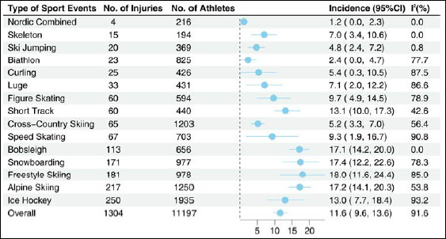

| Host year | Host country | Athletes | Female injuries | Male injuries | Major sports events of injury |
| --- | --- | --- | --- | --- | --- |
| 2022 | China | 2861 | 123 | 139 | Alpine skiing, Freestyle skiing, Ice hockey |
| 2018 | Republic of Korea | 2981 | 169 | 207 | Alpine skiing, Freestyle skiing, Ice hockey |
| 2014 | Russian Federation | 2788 | 168 | 219 | Alpine skiing, Freestyle skiing, Snowboarding |
| 2010 | Canada | 2567 | 137 | 142 | Alpine skiing, Snowboarding, Ice hockey |

See Also: https://www.olympics.com/ioc/news/ioc-injury-illness-surveillance-study-protecting-the-athletes-health

# Canada Games Injuries

Chimera NJ, Merasty D, Lininger MR. Injuries and Illnesses Across 10 Years of Canada Games Competitions: 2009 – 2019. IJSPT. 2022;17(7):1372-1382. doi:10.26603/001c.39743. PMID:36518838

https://ijspt.scholasticahq.com/article/39743-injuries-and-illnesses-across-10-years-of-canada-games-competitions-2009-2019

|  | Injury Incidence |  | Illness Incidence |  |
| --- | --- | --- | --- | --- |
|  | Male | Female | Male | Female |
| Alpine Skiing | 267.5 | 460.9 | 42.3 | 100.9 |
| Archery | 139.2 | 188.3 | 33.3 | 103.8 |
| Badminton | 548.2 | 456.4 | 58.4 | 86.2 |
| Biathlon | 356.8 | 633.3 | 34.3 | 84.0 |
| Boxing | 646.7 | N/A | 14.9 | N/A |
| Cross Country Skiing | 247.6 | 330.1 | 124.0 | 143.5 |
| Curling | 198.9 | 252.2 | 56.2 | 53.1 |
| Figure Skating | 197.0 | 141.9 | 55.3 | 68.4 |
| Freestyle Skiing | 774.2 | 1015.2 | 7.6 | 53.3 |
| Gymnastics | 717.4 | 539.0 | 40.9 | 44.2 |
| Ice Hockey | 337.2 | 310.2 | 76.3 | 54.5 |
| Judo | 464.2 | 621.5 | 77.8 | 81.6 |
| Ringette | N/A | 439.8 | N/A | 71.0 |
| Snowboarding | 524.7 | 732.7 | 45.7 | 36.8 |
| Speed Skating | 417.5 | 356.6 | 40.5 | 91.8 |
| Squash | 490.3 | 473.0 | 72.2 | 101.4 |
| Synchronized Swimming | N/A | 205.6 | N/A | 38.2 |
| Table Tennis | 174.0 | 175.9 | 50.3 | 97.1 |
| Target Shooting | 262.3 | 373.6 | 85.8 | 192.7 |
| Wheelchair Basketball | 607.7 | 888.4 | 121.1 | 168.0 |

# Canada Games Injuries

Chimera NJ, Merasty D, Lininger MR. Injuries and Illnesses Across 10 Years of Canada Games Competitions: 2009 – 2019. IJSPT. 2022;17(7):1372-1382. doi:10.26603/001c.39743. PMID:36518838

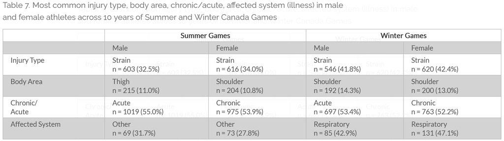

# Injurytools package

Preamble 1: packages

```r
library(worldfootballR)
library(injurytools)
library(plyr)
library(dplyr)
library(stringr)

library(ggplot2)
library(gridExtra)
library(grid)
library(knitr)
```

```r
library(worldfootballR)
library(injurytools)
library(plyr)
library(dplyr)
```

```r
library(stringr)

library(ggplot2)
library(gridExtra)
library(grid)
library(knitr)
```

# Injurytools package

Preamble 2: Custom Functions

```r
convert_profile_url_to_injury = function(profile_url)
{
  # In: https://www.transfermarkt.com/edu-ribeiro/profil/spieler/371250
  # Out: https://www.transfermarkt.com/edu-ribeiro/verletzungen/spieler/371250/plus/1

  url = profile_url
  url = str_replace(url, "/profil/", "/verletzungen/")
  url = paste0(url, "/plus/1")
  return(url)
}




get_injuries_player = function(player_url, player_name)
{
  inj_url = convert_profile_url_to_injury(player_url)
  player_id = str_extract(player_url, "[0-9]+")



  injuries_page <- xml2::read_html(inj_url)
  injuries_page <- injuries_page %>% rvest::html_nodes("#yw1") %>%
    rvest::html_nodes("tbody")

  if(length(injuries_page) == 0){nInjuries = 0}

  if(length(injuries_page) >= 1)
  {
    injuries_page <- injuries_page %>% .[[1]] %>% rvest::html_children()
  }



  nInjuries = length(injuries_page)

  season = character(0)
  injury = character(0)
  since = character(0)
  until = character(0)
  days_lost = character(0)
  games_lost = character(0)

  injury_acl = character(0)
  injury_type = character(0)
  injury_severity = character(0)


  if(nInjuries >= 1)
  {
    for(injury_count in 1:nInjuries)
    {
      inj_text = as.character(injuries_page[injury_count])
      inj_bits = unlist(str_extract_all(inj_text, ">.*<"))
      inj_bits = str_replace_all(inj_bits, ">|<", "")
      season = c(season, inj_bits[1])
      injury = c(injury, inj_bits[2])
      since = c(since, inj_bits[3])
      until = c(until, inj_bits[4])

      days_lost1 = str_extract(inj_text, "[0-9]+ days<")
      days_lost1 = str_replace(days_lost1, " days<", "")
      days_lost = c(days_lost, days_lost1)

      games_lost1 = str_extract(inj_text, "span>[0-9]+")
      games_lost1 = str_replace(games_lost1, "span>", "")
      games_lost = c(games_lost, games_lost1)

    }

    since = tm_fix_dates2(since)
    until = tm_fix_dates2(until)

    injury_acl = rep("NO_ACL", nInjuries)
    injury_acl[str_detect(injury, "Cruciate Ligament")] = "ACL"

    injury_type = rep("Unknown", nInjuries)
    injury_type[str_detect(injury, "Ankle|Ligament")] = "Ligament"
    injury_type[str_detect(injury, "Fracture|Foot Injury|Hand Injury|Head Injury|Hip Injury|Pelvis Injury")] = "Bone"
    injury_type[str_detect(injury, "Knock|Concussion")] = "Concussion"
    injury_type[str_detect(injury, "Calf|Groin|Hamstring|Muscl|Pubitis|Thigh")] = "Muscle"

    days_lost = as.numeric(days_lost)
    games_lost =as.numeric(games_lost)

    injury_severity = rep("Minor", nInjuries)
    injury_severity[days_lost >= 7] = "Moderate"
    injury_severity[days_lost >= 28] = "Severe"
    injury_severity[days_lost >= 90] = "Very_severe"


  }

  player_name = rep(player_name, nInjuries)
  player_id = rep(player_id, nInjuries)
  player_url = rep(player_url, nInjuries)
  inj_url = rep(inj_url, nInjuries)
  from = since

  out_df = data.frame(player_name, player_id, season, injury, from, until, days_lost, games_lost, injury,
                      injury_acl, injury_type, injury_severity)


  return(out_df)
}




# Had to patch: https://github.com/JaseZiv/worldfootballR/blob/main/R/internals.R

tm_fix_dates2 <- function(dirty_dates) {

  fix_date <- function(dirty_date) {
    #print(dirty_date)

    dirty3 = unlist(stringr::str_split_fixed(dirty_date, "/", 3))
    dirty_date = paste0(dirty3[3],"-",dirty3[2],"-",dirty3[1])
    dirty_date[dirty_date == "--"] = NA
    clean_date = dirty_date
    return(clean_date)


    return(clean_date)
  }

  clean_dates <- dirty_dates %>% purrr::map_chr(fix_date)

  return(clean_dates)
}
```

# Injurytools package

Preamble 3: Data Cleaning

```r
start_year = 2024
br_team_urls <- tm_league_team_urls(country_name = "Brazil", start_year = start_year)
br_team_urls
```

```
##  [1] "https://www.transfermarkt.com/flamengo-rio-de-janeiro/startseite/verein/614/saison_id/2024"
##  [2] "https://www.transfermarkt.com/se-palmeiras-sao-paulo/startseite/verein/1023/saison_id/2024"
##  [3] "https://www.transfermarkt.com/botafogo-rio-de-janeiro/startseite/verein/537/saison_id/2024"
##  [4] "https://www.transfermarkt.com/fc-santos/startseite/verein/221/saison_id/2024"
##  [5] "https://www.transfermarkt.com/clube-atletico-mineiro/startseite/verein/330/saison_id/2024"
##  [6] "https://www.transfermarkt.com/gremio-porto-alegre/startseite/verein/210/saison_id/2024"
##  [7] "https://www.transfermarkt.com/vasco-da-gama-rio-de-janeiro/startseite/verein/978/saison_id/2024"
##  [8] "https://www.transfermarkt.com/ec-cruzeiro-belo-horizonte/startseite/verein/609/saison_id/2024"
##  [9] "https://www.transfermarkt.com/corinthians-sao-paulo/startseite/verein/199/saison_id/2024"
## [10] "https://www.transfermarkt.com/fc-sao-paulo/startseite/verein/585/saison_id/2024"
## [11] "https://www.transfermarkt.com/esporte-clube-bahia/startseite/verein/10010/saison_id/2024"
## [12] "https://www.transfermarkt.com/fluminense-rio-de-janeiro/startseite/verein/2462/saison_id/2024"
## [13] "https://www.transfermarkt.com/red-bull-bragantino/startseite/verein/8793/saison_id/2024"
## [14] "https://www.transfermarkt.com/sc-internacional-porto-alegre/startseite/verein/6600/saison_id/2024"
## [15] "https://www.transfermarkt.com/fortaleza-esporte-clube/startseite/verein/10870/saison_id/2024"
## [16] "https://www.transfermarkt.com/sport-club-do-recife/startseite/verein/8718/saison_id/2024"
## [17] "https://www.transfermarkt.com/esporte-clube-vitoria/startseite/verein/2125/saison_id/2024"
## [18] "https://www.transfermarkt.com/ceara-sporting-club/startseite/verein/2029/saison_id/2024"
## [19] "https://www.transfermarkt.com/esporte-clube-juventude/startseite/verein/10492/saison_id/2024"
## [20] "https://www.transfermarkt.com/mirassol-futebol-clube-sp-/startseite/verein/3876/saison_id/2024"
```

```r
for(teamcount in 1:length(br_team_urls))
{
  br_squad = tm_squad_stats(team_url = br_team_urls[teamcount])
  if(teamcount == 1){br_squad_all = br_squad}
  if(teamcount > 1){br_squad_all = rbind(br_squad_all, br_squad)}
  Sys.sleep(5)
  print(teamcount)
}


br_squad_all$player_id = str_extract(br_squad_all$player_url, "[0-9]+$")
br_squad_all$start_year = start_year

br_squad_all = subset(br_squad_all, team_name == "São Paulo Futebol Clube")
```

```r
br_squad_all = read.csv("Br_Squad_All.csv")

# Get the exposures
raw_br_exposures = ddply(br_squad_all, "player_id", summarize,
                         player_name = player_name[1],
                         year = start_year[1],
                         minutes_played = sum(minutes_played))
```

```r
# Get the injuries
for(playercount in 1:nrow(br_squad_all))
{
  this_inj_df = get_injuries_player(br_squad_all$player_url[playercount],
                                    br_squad_all$player_name[playercount])
  if(playercount == 1){br_inj_df = this_inj_df}
  if(playercount > 1){br_inj_df = rbind(br_inj_df, this_inj_df)}

  print(br_squad_all$player_url[playercount])
  Sys.sleep(5)
}
```

```r
br_inj_df = read.csv("Br_Inj_Df.csv")

br_inj_df$from = as.Date(br_inj_df$from)
br_inj_df$until = as.Date(br_inj_df$until)
br_inj_df = subset(br_inj_df, !is.na(from) & !is.na(until))
```

```r
head(br_inj_df)
```

```
##       player_name player_id season        injury       from      until
## 1         Jandrei    512344  22/23   Hand injury 2023-05-10 2023-06-30
## 2         Jandrei    512344  22/23      fracture 2022-07-28 2022-08-17
## 3         Jandrei    512344  22/23 Back problems 2022-07-17 2022-07-26
## 4         Jandrei    512344  20/21  Corona virus 2020-11-24 2020-12-10
## 5           Young    894532  24/25   Foot injury 2025-01-17 2025-04-13
## 6 Leandro Mathias    838386  25/26 Knee problems 2025-08-31 2025-11-26
##   days_lost games_lost      injury.1 injury_acl injury_type injury_severity
## 1        52         11   Hand injury     NO_ACL     Unknown          Severe
## 2        21          6      fracture     NO_ACL     Unknown        Moderate
## 3        10          2 Back problems     NO_ACL     Unknown        Moderate
## 4        17          3  Corona virus     NO_ACL     Unknown        Moderate
## 5        87         18   Foot injury     NO_ACL     Unknown          Severe
## 6        88         15 Knee problems     NO_ACL     Unknown          Severe
```

# Injurytools package

More data prep, as per https://cran.r-project.org/web/packages/injurytools/vignettes/prepare-injury-data.html

```r
df_injuries <- prepare_inj(df_injuries0   = br_inj_df,
                           person_id      = "player_name",
                           date_injured   = "from",
                           date_recovered = "until")
head(df_injuries)
```

```
##         person_id player_id season        injury date_injured date_recovered
## 1         Jandrei    512344  22/23   Hand injury   2023-05-10     2023-06-30
## 2         Jandrei    512344  22/23      fracture   2022-07-28     2022-08-17
## 3         Jandrei    512344  22/23 Back problems   2022-07-17     2022-07-26
## 4         Jandrei    512344  20/21  Corona virus   2020-11-24     2020-12-10
## 5           Young    894532  24/25   Foot injury   2025-01-17     2025-04-13
## 6 Leandro Mathias    838386  25/26 Knee problems   2025-08-31     2025-11-26
##   days_lost games_lost      injury.1 injury_acl injury_type injury_severity
## 1        52         11   Hand injury     NO_ACL     Unknown          Severe
## 2        21          6      fracture     NO_ACL     Unknown        Moderate
## 3        10          2 Back problems     NO_ACL     Unknown        Moderate
## 4        17          3  Corona virus     NO_ACL     Unknown        Moderate
## 5        87         18   Foot injury     NO_ACL     Unknown          Severe
## 6        88         15 Knee problems     NO_ACL     Unknown          Severe
```

```r
df_exposures <- prepare_exp(df_exposures0 = raw_br_exposures,
                            person_id     = "player_name",
                            date          = "year",
                            time_expo     = "minutes_played")

head(df_exposures)
```

```
##   player_id     person_id date time_expo
## 1     10471  Luiz Gustavo 2024       871
## 2     68097        Rafael 2024      5224
## 3     72441  Rafael Tolói 2024       501
## 4     77100   Lucas Moura 2024      1467
## 5     85314         Oscar 2024      1484
## 6    112988 Cédric Soares 2024      3121
```

```r
injd <-  prepare_all(data_exposures = df_exposures,
                       data_injuries  = df_injuries,
                       exp_unit = "matches_minutes")
head(injd)
```

```
## # A tibble: 6 × 20
##   person_id     t0         tf         date_injured date_recovered tstart
##   <fct>         <date>     <date>     <date>       <date>         <date>
## 1 Alan Franco   2024-07-01 2025-06-30 NA           NA             2024-07-01
## 2 Alisson       2024-07-01 2025-06-30 2024-07-18   2024-11-09     2024-07-01
## 3 Alisson       2024-07-01 2025-06-30 NA           NA             2024-11-09
## 4 André Silva   2024-07-01 2025-06-30 NA           NA             2024-07-01
## 5 Cédric Soares 2024-07-01 2025-06-30 2025-05-27   2025-05-30     2024-07-01
## 6 Cédric Soares 2024-07-01 2025-06-30 NA           NA             2025-05-30
## # ℹ 14 more variables: tstop <date>, tstart_minPlay <dbl>, tstop_minPlay <dbl>,
## #   status <dbl>, enum <dbl>, days_lost <dbl>, player_id <int>, season <chr>,
## #   injury <chr>, games_lost <int>, injury.1 <chr>, injury_acl <chr>,
## #   injury_type <chr>, injury_severity <chr>
```

# Injurytools package

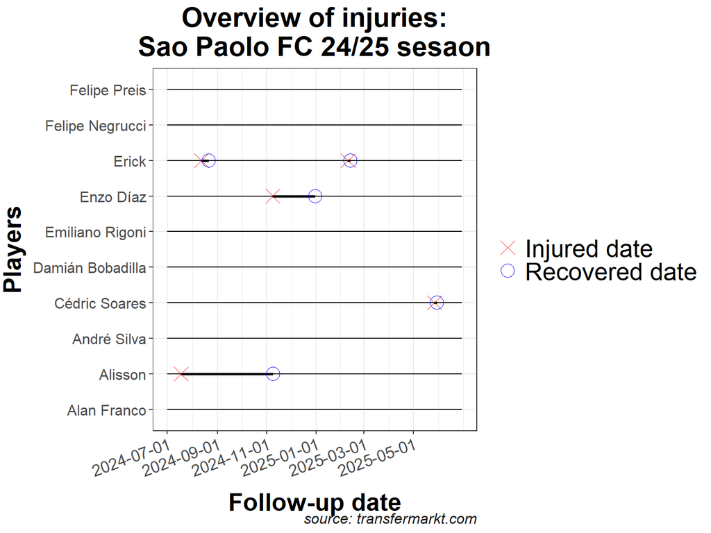

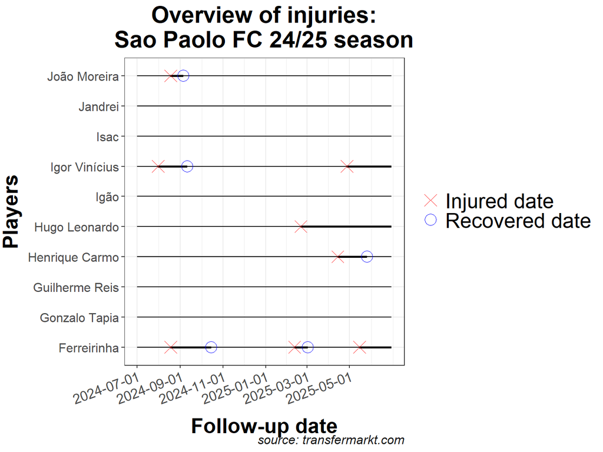

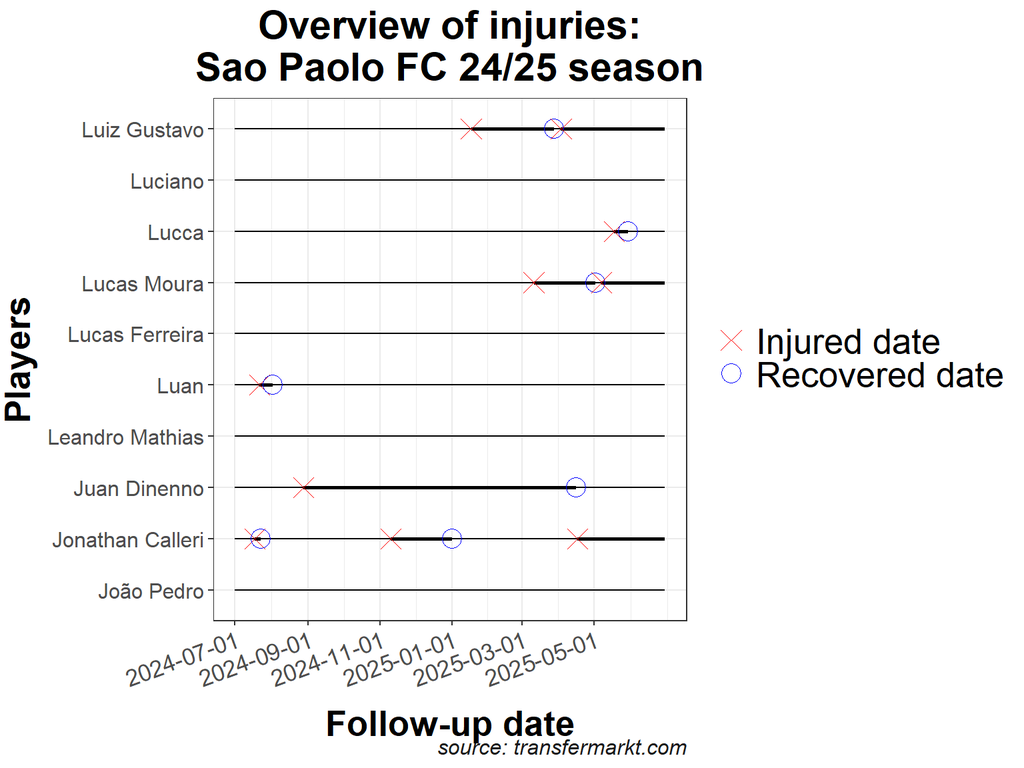

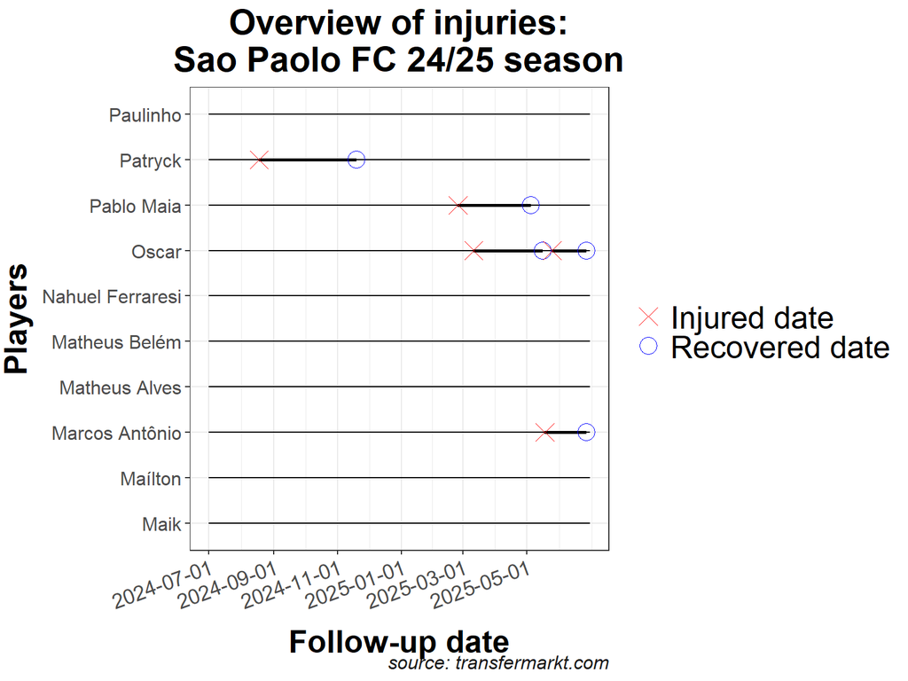

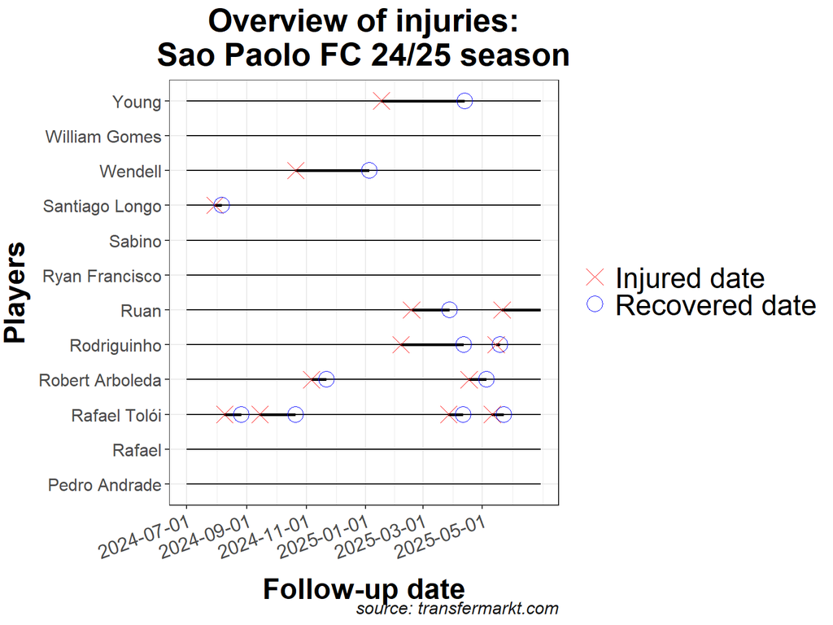

```r
player_list = unique(injd$person_id)
injd1 = subset(injd, person_id %in% player_list[1:10])
injd2 = subset(injd, person_id %in% player_list[11:20])
injd3 = subset(injd, person_id %in% player_list[21:30])
injd4 = subset(injd, person_id %in% player_list[31:40])
injd5 = subset(injd, person_id %in% player_list[41:52])


gg_photo(injd1,
         title   = "Overview of injuries:\nSao Paolo FC 24/25 sesaon",
         by_date = "2 month",
         fix     = TRUE) +
  ## plus some lines of ggplot2 code..
  xlab("Follow-up date") + ylab("Players") + labs(caption = "source: transfermarkt.com") +
  theme(plot.title = element_text(face = "bold", hjust = 0.5, size = 22),
        axis.text.x.bottom = element_text(size = 13, angle = 20, hjust = 1),
        axis.text.y.left   = element_text(size = 12),
        axis.title.x       = element_text(size = 20, face = "bold", vjust = -1),
        axis.title.y       = element_text(size = 20, face = "bold", vjust = 1.8),
        legend.text        = element_text(size = 20),
        plot.caption       = element_text(face = "italic", size = 12, colour = "gray10"))
```

# Injurytools package

```r
df_summary        <- calc_summary(injd)
df_summary_perinj <- calc_summary(injd, by = "injury_type")
df_summary |>
  mutate(incidence_new = paste0(round(incidence, 2), " (", round(incidence_lower, 2), ",", round(incidence_upper, 2), ")"),
         burden_new    = paste0(round(burden, 2), " (", round(burden_lower, 2), ",", round(burden_upper, 2), ")")) |>
  dplyr::select(2, 7, 1, incidence_new, burden_new) |>
  kable(col.names = c("N injuries", "N days lost", "Total expo", "Incidence (95% CI)", "Burden (95% CI)"),
        caption   = "Injury incidence and injury burden are reported as 100 player-matches",
        align     = "c")
```

Injury incidence and injury burden are reported as 100 player-matches

| N injuries | N days lost | Total expo | Incidence (95% CI) | Burden (95% CI) |
| --- | --- | --- | --- | --- |
| 41 | 2579 | 64990 | 5.68 (3.94,7.42) | 357.15 (343.36,370.93) |

```r
df_summary_perinj |>
  mutate(incidence_new = paste0(round(incidence, 2), " (", round(incidence_lower, 2), ",", round(incidence_upper, 2), ")"),
         burden_new    = paste0(round(burden, 2), " (", round(burden_lower, 2), ",", round(burden_upper, 2), ")")) |>
  dplyr::select(1:2, 9, 4, incidence_new, burden_new) |>
  kable(col.names = c("Type of injury", "N injuries", "N days lost", "Total expo", "Incidence (95% CI)", "Burden (95% CI)"),
        caption   = "Injury incidence and injury burden are reported as 100 player-matches",
        align     = "c")
```

Injury incidence and injury burden are reported as 100 player-matches

| Type of injury | N injuries | N days lost | Total expo | Incidence (95% CI) | Burden (95% CI) |
| --- | --- | --- | --- | --- | --- |
| Concussion | 1 | 42 | 64990 | 0.14 (0,0.41) | 5.82 (4.06,7.58) |
| Ligament | 3 | 19 | 64990 | 0.42 (0,0.89) | 2.63 (1.45,3.81) |
| Muscle | 13 | 358 | 64990 | 1.8 (0.82,2.78) | 49.58 (44.44,54.71) |
| Unknown | 24 | 2160 | 64990 | 3.32 (1.99,4.65) | 299.12 (286.51,311.74) |

# Injurytools package

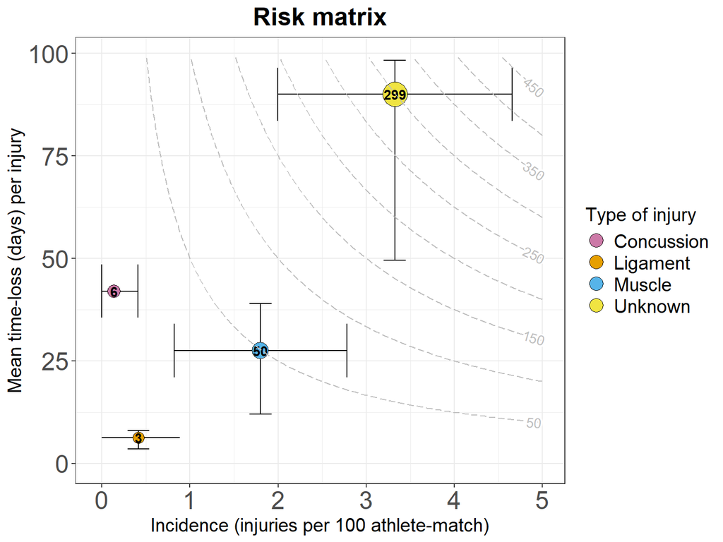

```r
# warnings set to FALSE
palette <- c("#000000", Ligament = "#E69F00", Muscle = "#56B4E9", "#009E73",
             Unknown = "#F0E442", "#0072B2", Bone = "#D55E00", Concussion = "#CC79A7")
# source of the palette: http://www.cookbook-r.com/Graphs/Colors_(ggplot2)/
theme3 <- theme(plot.title = element_text(face = "bold", hjust = 0.5, size = 20),
                axis.text.x.bottom = element_text(size = 20),
                axis.text.y.left = element_text(size = 20),
                axis.title.x = element_text(size = 15),
                axis.title.y = element_text(size = 15),
                legend.title = element_text(size = 15),
                legend.text = element_text(size = 15))

gg_riskmatrix(injd,
              by = "injury_type",
              title = "Risk matrix") +
  scale_fill_manual(name = "Type of injury",
                    values = palette) +
  guides(fill = guide_legend(override.aes = list(size = 5))) +
  theme3
```

# Injurytools package

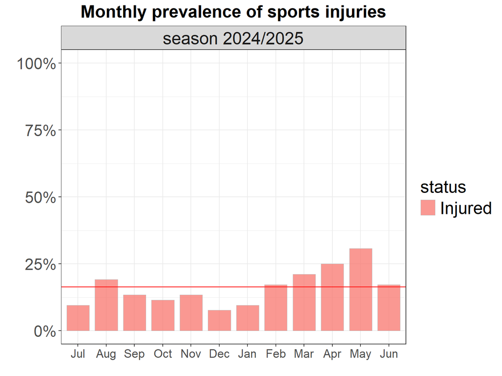

```r
theme4 <- theme(plot.title = element_text(face = "bold", hjust = 0.5, size = 20),
                axis.text.x = element_text(size = 13.5),
                axis.text.y = element_text(size = 18),
                legend.title = element_text(size = 20),
                legend.text = element_text(size = 20),
                strip.text = element_text(size = 20))


gg_prevalence(injd, time_period = "monthly",
              line_mean = TRUE,
              title = "Monthly prevalence of sports injuries") +
  theme4
```